# Script to get validated points from the ReSurvey database using best RF model

Alicia Valdés

16 junio 2026

This R script is used get validated points from the ReSurvey database using the best RF model (Landsat, months).

# Load libraries

```r
library(tidyverse)
library(here)
library(rnaturalearth)
library(sf)
library(patchwork)
library(scales)
library(gridExtra)
library(cowplot)
```

# Load functions

```r
knitr::purl("functions_20260225.Rmd", output = "functions_20260225.R")
```

```
[1] "functions_20260225.R"
```

```r
source("functions_20260225.R")
```

# Load previously created objects

```r
# Define the folder path
folder_path <- here("objects", "validated_points")

# List all .RData or .rda files in the folder
rdata_files <- list.files(folder_path, full.names = TRUE)

# Load each file
lapply(rdata_files, load, envir = .GlobalEnv)
```

```
[[1]]
[1] "prediction_Landsat_prob"

[[2]]
[1] "prediction_Landsat_resp"
```

# Load best model

Model with months, Landsat:

```r
# Load best model - Accuracy = 0.852 (without k-fold)
rf_months_Landsat <- get(load(here("objects", "RF_1500_20260318",
                               "rf_months_Landsat_refin_20_10_2x_model.Rdata")))$model
```

# Read data

Read data validation Landsat:

```r
data_validation <- read_tsv(here(
  "data", "clean","final_RS_data_bands_Landsat_all_20260309.csv"))
```

No parsing issues!

```r
nrow(data_validation)
```

```
[1] 121494
```

Read original db:

```r
data_V2025.2 <- read_tsv(
  "C:/Data/MOTIVATE/MOTIVATE_data/Data/EVA and ReSurvey Data/2025 data - V2025.2/Core data/200_Motivate20250415_notJUICE_header_with_precise_coordinates.csv")
```

# Define lists of predictor variables

```r
# Excluding EVI because many values outside of range -1, 1
vars_RF_months_Landsat <- c(
  # Min values of all indices
  "NDVI_min", "NDMI_min", "NDWI_min", "SAVI_min",
  # Max values of NDMI and NDWI
  "NDMI_max", "NDWI_max",
  # AUC of NDVI, and SAVI between march and oct
  "NDVI_auc_mar_oct", "SAVI_auc_mar_oct",
  # Values of NDVI and SAVI at march, pos and oct
  "NDVI_avg_value_03", "NDVI_pos_value", "NDVI_avg_value_10",
  "SAVI_avg_value_03", "SAVI_pos_value", "SAVI_avg_value_10",
  # Differences pos-march in value and doy
  "NDVI_diff_pos_march_value", "SAVI_diff_pos_march_value",
  "NDVI_diff_pos_march_doy", "SAVI_diff_pos_march_doy",
  # Differences pos-oct in value and doy
  "NDVI_diff_pos_oct_value", "SAVI_diff_pos_oct_value",
  "NDVI_diff_pos_oct_doy", "SAVI_diff_pos_oct_doy")
```

# Apply similar filtering as to prepare data for models

First, we were predicting in all data, even with missing values in predictors and values out ot the expected ranges!

```r
data_validation_filtered <- data_validation %>%
  # Data filtering
  # Remove rows with missing values in predictors
  dplyr::filter(if_all(all_of(vars_RF_months_Landsat), ~ !is.na(.))) %>%
  # Remove all rows with wrong values of indices (not between -1 and 1)
  dplyr::filter(NDVI_max <= 1 & NDVI_min >= -1) %>%
  # With Landsat data, many observations removed because of high/low EVI values
  # In Landsat_extraction, values of EVI outside of expected range were set as NA,
  # so better not to use EVI here
  # dplyr::filter(EVI_max <= 1 & EVI_min >= -1) %>%
  dplyr::filter(SAVI_max <= 1 & SAVI_min >= -1) %>%
  dplyr::filter(NDMI_max <= 1 & NDMI_min >= -1) %>%
  dplyr::filter(NDWI_max <= 1 & NDWI_min >= -1) %>%
  # Keep only rows with differences > 0 in variables
  filter(if_all(any_of(vars_RF_months_Landsat[grepl("diff",
                                                   vars_RF_months_Landsat)]),
                ~ .x > 0)) %>%
  # Rough validation based on NDWI
  rough_validation_Landsat()
```

```r
nrow(data_validation_filtered)
```

```
[1] 100990
```

# Predictions from best models

Predict in data without NAs!

Model with months, Landsat for predicting EVERYWHERE:

```r
predictions <- c("prediction_Landsat_resp", "prediction_Landsat_prob")
```

Add predictions:

```r
data_validated <- data_validation %>%
  left_join(
    # Predictions from model with months, Landsat
    cbind(
      data.frame(
        # PlotObservationIDs
        PlotObservationID = data_validation_filtered %>%
          pull(PlotObservationID),
        # Prediction response
        pred_Landsat_resp = prediction_Landsat_resp
        ),
      # Prediction probabilities
      do.call(rbind, prediction_Landsat_prob) %>% as.data.frame() %>%
        rename(pred_Landsat_Q = EUNIS1.Q, pred_Landsat_R = EUNIS1.R,
               pred_Landsat_S = EUNIS1.S, pred_Landsat_T = EUNIS1.T)
      )
  ) %>%
  # Validated or not (Landsat)
  mutate(valid_Landsat = ifelse(pred_Landsat_resp == EUNIS1, TRUE,
                                ifelse(is.na(pred_Landsat_resp), NA, FALSE)))
```

# Counts

```r
data_validated %>% count(valid_Landsat)
```

| valid_Landsat | n |
| --- | --- |
| FALSE | 35615 |
| TRUE | 65375 |
| NA | 20504 |

# Data cleaning

```r
data_validated_clean <- data_validated %>%
  # Keep only needed cols
  select(PlotObservationID, year, biogeo, unit, EUNIS1, EUNIS2,
         pred_Landsat_resp, pred_Landsat_Q, pred_Landsat_R, pred_Landsat_S,
         pred_Landsat_T, valid_Landsat)
```

How many NAs for each row?

```r
data_validated_clean %>%
  summarise(across(everything(), ~ sum(is.na(.))))
```

| PlotObservationID | year | biogeo | unit | EUNIS1 | EUNIS2 | pred_Landsat_resp | pred_Landsat_Q | pred_Landsat_R | pred_Landsat_S | pred_Landsat_T | valid_Landsat |
| --- | --- | --- | --- | --- | --- | --- | --- | --- | --- | --- | --- |
| 0 | 0 | 0 | 2511 | 0 | 22306 | 20504 | 20504 | 20504 | 20504 | 20504 | 20504 |

# Get info from original db

## Read original db

```r
data_V2025.2 <- read_tsv(
  "C:/Data/MOTIVATE/MOTIVATE_data/Data/EVA and ReSurvey Data/2025 data - V2025.2/Core data/200_Motivate20250415_notJUICE_header_with_precise_coordinates.csv")
```

## Get info for cols where there were NAs

```r
data_validated_clean <- left_join(
  data_validated_clean,
  data_V2025.2 %>%
    # Select cols where there were NAs
    select(RS_CODE, `ReSurvey site`, `ReSurvey plot`, `ReSurvey observation`,
           PlotObservationID, `Date of recording`, `Location method`),
  by = "PlotObservationID")
```

## Add coordinates

```r
data_validated_clean <- data_validated_clean %>%
  left_join(
    data_V2025.2 %>%
      # Update coordinates
      mutate(Lon_updated = ifelse(is.na(Lon_prec), Longitude, Lon_prec),
             Lat_updated = ifelse(is.na(Lat_prec), Latitude, Lat_prec)) %>%
      # Select columns needed
      select(PlotObservationID, Lon_updated, Lat_updated)
    )
```

How many NAs for each row?

```r
data_validated_clean %>%
  summarise(across(everything(), ~ sum(is.na(.))))
```

| PlotObservationID | year | biogeo | unit | EUNIS1 | EUNIS2 | pred_Landsat_resp | pred_Landsat_Q | pred_Landsat_R | pred_Landsat_S | pred_Landsat_T | valid_Landsat | RS_CODE | ReSurvey site | ReSurvey plot | ReSurvey observation | Date of recording | Location method | Lon_updated | Lat_updated |
| --- | --- | --- | --- | --- | --- | --- | --- | --- | --- | --- | --- | --- | --- | --- | --- | --- | --- | --- | --- |
| 0 | 0 | 0 | 2511 | 0 | 22306 | 20504 | 20504 | 20504 | 20504 | 20504 | 20504 | 0 | 0 | 0 | 0 | 0 | 13310 | 0 | 0 |

# More data cleaning

```r
data_validated_clean <- data_validated_clean %>%
  # Convert to date
  mutate(`Date of recording` = dmy(`Date of recording`))
```

# Obs with more than one row

```r
data_validated_clean %>%
  # These 4 cols uniquely identify each obs
  group_by(RS_CODE, `ReSurvey site`, `ReSurvey plot`, `ReSurvey observation`) %>%
  # Filter obs with more than 1 row
  filter(n() > 1) %>%
  arrange(RS_CODE, `ReSurvey site`, `ReSurvey plot`, `ReSurvey observation`)
```

| PlotObservationID | year | biogeo | unit | EUNIS1 | EUNIS2 | pred_Landsat_resp | pred_Landsat_Q | pred_Landsat_R | pred_Landsat_S | pred_Landsat_T | valid_Landsat | RS_CODE | ReSurvey site | ReSurvey plot | ReSurvey observation | Date of recording | Location method | Lon_updated | Lat_updated |
| --- | --- | --- | --- | --- | --- | --- | --- | --- | --- | --- | --- | --- | --- | --- | --- | --- | --- | --- | --- |
| 338975 | 1989 | ALP | ALPS | R | R2 | R | 2.903570e-01 | 0.597223798 | 1.124192e-01 | 0.000000e+00 | TRUE | CH_0013 | Martisberg | 6 | 1989 | 1989-01-01 | 01 | 8.104609 | 46.38956 |
| 338976 | 1989 | ALP | ALPS | R | R2 | R | 2.903570e-01 | 0.597223798 | 1.124192e-01 | 0.000000e+00 | TRUE | CH_0013 | Martisberg | 6 | 1989 | 1989-01-01 | 01 | 8.104609 | 46.38956 |
| 7795 | 2019 | PANONIA | NA | R | R1 | R | 1.170494e-03 | 0.991505925 | 7.265160e-03 | 5.842093e-05 | TRUE | CZ_0011 | AU | AUa | AUa-NewDissi-2019 | 2019-06-10 | Location from a description | 16.007500 | 48.80700 |
| 7796 | 2019 | PANONIA | NA | R | R1 | R | 8.938875e-04 | 0.998982697 | 6.499415e-05 | 5.842093e-05 | TRUE | CZ_0011 | AU | AUa | AUa-NewDissi-2019 | 2019-06-10 | Location from a description | 16.007722 | 48.80686 |
| 6305 | 2019 | CON | AUSTRIA | S | Sb | NA | NA | NA | NA | NA | NA | CZ_0019_025 | KRAL_SNEZNIK | KRAL_SNEZNIK01 | KRAL_SNEZNIK01_2019 | 2019-07-08 | Location from a description | 16.851300 | 50.20452 |
| 6306 | 2019 | CON | AUSTRIA | S | S4 | NA | NA | NA | NA | NA | NA | CZ_0019_025 | KRAL_SNEZNIK | KRAL_SNEZNIK01 | KRAL_SNEZNIK01_2019 | 2019-07-08 | Location from a description | 16.851333 | 50.20457 |
| 6307 | 2019 | CON | AUSTRIA | S | S2 | NA | NA | NA | NA | NA | NA | CZ_0019_025 | KRAL_SNEZNIK | KRAL_SNEZNIK01 | KRAL_SNEZNIK01_2019 | 2019-07-08 | Location from a description | 16.851367 | 50.20465 |
| 6308 | 2019 | CON | AUSTRIA | S | Sb | NA | NA | NA | NA | NA | NA | CZ_0019_025 | KRAL_SNEZNIK | KRAL_SNEZNIK02 | KRAL_SNEZNIK02_2019 | 2019-07-08 | Location from a description | 16.851000 | 50.20510 |
| 6309 | 2019 | CON | POLAND | T | T3 | NA | NA | NA | NA | NA | NA | CZ_0019_025 | KRAL_SNEZNIK | KRAL_SNEZNIK02 | KRAL_SNEZNIK02_2019 | 2019-07-08 | Location from a description | 16.851150 | 50.20515 |
| 6310 | 2019 | CON | AUSTRIA | S | Sb | NA | NA | NA | NA | NA | NA | CZ_0019_025 | KRAL_SNEZNIK | KRAL_SNEZNIK02 | KRAL_SNEZNIK02_2019 | 2019-07-08 | Location from a description | 16.850967 | 50.20525 |

[output cut: 990 more lines]

For each unique combination of RS_CODE, ReSurvey site, ReSurvey plot and ReSurvey observation, check whether any of the other columns (except PlotObservationID) differ across the rows in that group:

```r
data_validated_clean %>%
  group_by(
    RS_CODE, `ReSurvey site`, `ReSurvey plot`, `ReSurvey observation`
  ) %>%
  filter(n() > 1) %>%
  group_modify(~ {

    # Exclude columns that should NOT be checked
    cols_to_check <- setdiff(names(.x), "PlotObservationID")

    # Identify columns where at least one value differs
    diffs <- map_lgl(.x[cols_to_check], ~ n_distinct(.x, na.rm = FALSE) > 1)

    tibble(
      differing_columns = paste(names(diffs)[diffs], collapse = ", ")
      )
    }) %>%
  ungroup() %>%
  # Keep only groups where at least one difference exists
  filter(differing_columns != "")
```

| RS_CODE | ReSurvey site | ReSurvey plot | ReSurvey observation | differing_columns |
| --- | --- | --- | --- | --- |
| CZ_0011 | AU | AUa | AUa-NewDissi-2019 | pred_Landsat_Q, pred_Landsat_R, pred_Landsat_S, Lon_updated, Lat_updated |
| CZ_0019_025 | KRAL_SNEZNIK | KRAL_SNEZNIK01 | KRAL_SNEZNIK01_2019 | EUNIS2, Lon_updated, Lat_updated |
| CZ_0019_025 | KRAL_SNEZNIK | KRAL_SNEZNIK02 | KRAL_SNEZNIK02_2019 | unit, EUNIS1, EUNIS2, Lon_updated, Lat_updated |
| CZ_0019_025 | KRAL_SNEZNIK | KRAL_SNEZNIK03 | KRAL_SNEZNIK03_2019 | Lon_updated, Lat_updated |
| CZ_0019_025 | KRAL_SNEZNIK | KRAL_SNEZNIK04 | KRAL_SNEZNIK04_2019 | EUNIS2, Lon_updated, Lat_updated |
| CZ_0019_025 | KRAL_SNEZNIK | KRAL_SNEZNIK05 | KRAL_SNEZNIK05_2019 | EUNIS1, EUNIS2, Lon_updated, Lat_updated |
| CZ_0019_025 | KRAL_SNEZNIK | KRAL_SNEZNIK06 | KRAL_SNEZNIK06_2019 | Lon_updated, Lat_updated |
| CZ_0019_025 | KRAL_SNEZNIK | KRAL_SNEZNIK07 | KRAL_SNEZNIK07_2019 | EUNIS1, EUNIS2, Lon_updated, Lat_updated |
| CZ_0019_025 | KRAL_SNEZNIK | KRAL_SNEZNIK08 | KRAL_SNEZNIK08_2019 | EUNIS1, EUNIS2, Lon_updated, Lat_updated |
| CZ_0019_025 | KRAL_SNEZNIK | KRAL_SNEZNIK09 | KRAL_SNEZNIK09_2019 | EUNIS2, Lon_updated, Lat_updated |

[output cut: 202 more lines]

# Add info on nr resurveys (n different years)

Some have only 1 year, either because the first year(s) were prior to Landsat, or because they were still not resurveyed.

```r
data_validated_clean <- data_validated_clean %>%
  group_by(RS_CODE, `ReSurvey site`, `ReSurvey plot`) %>%
  mutate(
    n_resurveys = n_distinct(year, na.rm = TRUE),   # count unique years
    first_year  = min(year, na.rm = TRUE),          # earliest year
    last_year   = max(year, na.rm = TRUE)           # latest year
  ) %>%
  ungroup()
```

# Add unique, self_created plot ID

```r
data_validated_clean <- data_validated_clean %>%
  mutate(
    plotID_AV = paste(RS_CODE, `ReSurvey site`, `ReSurvey plot`, sep = "_"))
```

# Get only latest obs for each plot

```r
data_validated_clean_latest <- data_validated_clean %>%
  # Keep only rows from the last year
  filter(year == last_year) %>%
  # These 3 cols are supposed to uniquely identify each plot
  group_by(RS_CODE, `ReSurvey site`, `ReSurvey plot`) %>%
  # If more than one row in the same year, keep the latest date
  #slice_max(`Date of recording`, n = 1, with_ties = FALSE) %>%
  ungroup()
```

## Obs with more than one row

```r
data_validated_clean_latest %>%
  group_by(plotID_AV) %>%
  # Filter obs with more than 1 row
  filter(n() > 1) %>%
  ungroup() %>%
  arrange(RS_CODE, `ReSurvey site`, `ReSurvey plot`)
```

| PlotObservationID | year | biogeo | unit | EUNIS1 | EUNIS2 | pred_Landsat_resp | pred_Landsat_Q | pred_Landsat_R | pred_Landsat_S | pred_Landsat_T | valid_Landsat | RS_CODE | ReSurvey site | ReSurvey plot | ReSurvey observation | Date of recording | Location method | Lon_updated | Lat_updated | n_resurveys | first_year | last_year | plotID_AV |
| --- | --- | --- | --- | --- | --- | --- | --- | --- | --- | --- | --- | --- | --- | --- | --- | --- | --- | --- | --- | --- | --- | --- | --- |
| 584483 | 2012 | ATL | BENELUX | S | Sa | R | 8.416658e-02 | 0.885331426 | 2.860695e-02 | 1.895044e-03 | FALSE | BE_0002a | wz | wz_17 | wz_17_20120723 | 2012-07-23 | 03 | 2.565940 | 51.08097 | 1 | 2012 | 2012 | BE_0002a_wz_wz_17 |
| 584484 | 2012 | ATL | BENELUX | S | Sa | R | 8.416658e-02 | 0.885331426 | 2.860695e-02 | 1.895044e-03 | FALSE | BE_0002a | wz | wz_17 | wz_17_20120725 | 2012-07-25 | 03 | 2.565940 | 51.08097 | 1 | 2012 | 2012 | BE_0002a_wz_wz_17 |
| 7838 | 2019 | CON | AUSTRIA | R | R1 | R | 4.063607e-02 | 0.945644973 | 5.026979e-03 | 8.691976e-03 | TRUE | CZ_0011 | A | Aa | Aa-NewDissi-2019 | 2019-06-30 | Location from a description | 17.091806 | 49.55567 | 2 | 1989 | 2019 | CZ_0011_A_Aa |
| 7839 | 2019 | CON | AUSTRIA | R | R1 | R | 5.778212e-02 | 0.705867675 | 0.000000e+00 | 2.363502e-01 | TRUE | CZ_0011 | A | Aa | Aa-NewSimil-2019 | 2019-06-30 | Location from a description | 17.092000 | 49.55658 | 2 | 1989 | 2019 | CZ_0011_A_Aa |
| 7836 | 2019 | CON | AUSTRIA | R | NA | R | 5.082150e-02 | 0.927348459 | 1.634853e-03 | 2.019519e-02 | TRUE | CZ_0011 | A | Ab | Ab-NewSimil-2019 | 2019-06-30 | Location from a description | 17.092056 | 49.55575 | 2 | 1989 | 2019 | CZ_0011_A_Ab |
| 7837 | 2019 | CON | AUSTRIA | R | NA | R | 9.359604e-03 | 0.983653137 | 4.600142e-03 | 2.387117e-03 | TRUE | CZ_0011 | A | Ab | Ab-NewDissi-2019 | 2019-06-30 | Location from a description | 17.091528 | 49.55578 | 2 | 1989 | 2019 | CZ_0011_A_Ab |
| 7803 | 2019 | PANONIA | NA | R | R1 | R | 4.020647e-03 | 0.994834572 | 1.086360e-03 | 5.842093e-05 | TRUE | CZ_0011 | AA | AAb | AAb-NewDissi-2019 | 2019-06-11 | Location from a description | 16.359389 | 48.98422 | 1 | 2019 | 2019 | CZ_0011_AA_AAb |
| 7804 | 2019 | PANONIA | NA | R | R1 | R | 6.061463e-03 | 0.959398579 | 3.448154e-02 | 5.842093e-05 | TRUE | CZ_0011 | AA | AAb | AAb-NewSimil-2019 | 2019-06-11 | Location from a description | 16.359389 | 48.98397 | 1 | 2019 | 2019 | CZ_0011_AA_AAb |
| 7857 | 2019 | PANONIA | NA | R | NA | R | 1.902812e-01 | 0.516827405 | 2.928914e-01 | 0.000000e+00 | TRUE | CZ_0011 | AB | ABa | ABa-NewDissi-2019 | 2019-07-07 | Location from a description | 16.330361 | 48.95722 | 2 | 1987 | 2019 | CZ_0011_AB_ABa |
| 7858 | 2019 | PANONIA | NA | R | R1 | R | 2.022881e-02 | 0.874579910 | 1.051018e-01 | 8.950949e-05 | TRUE | CZ_0011 | AB | ABa | ABa-NewSimil-2019 | 2019-07-07 | Location from a description | 16.330278 | 48.95747 | 2 | 1987 | 2019 | CZ_0011_AB_ABa |

[output cut: 990 more lines]

# Write csvs

```r
write_csv(data_validated_clean,
          here("data", "clean","data_validated_clean_20260318.csv"))
write_csv(data_validated_clean_latest,
          here("data", "clean","data_validated_clean_latest_20260318.csv"))
```

# Counts of validated / not-validated obs

## General

```r
data_validated_clean %>%
  count(valid_Landsat) %>%
  mutate(percent = n / sum(n) * 100)
```

| valid_Landsat | n | percent |
| --- | --- | --- |
| FALSE | 35615 | 29.31420 |
| TRUE | 65375 | 53.80924 |
| NA | 20504 | 16.87655 |

```r
data_validated_clean %>%
  filter(!is.na(valid_Landsat)) %>%
  count(valid_Landsat) %>%
  mutate(percent = n / sum(n) * 100)
```

| valid_Landsat | n | percent |
| --- | --- | --- |
| FALSE | 35615 | 35.26587 |
| TRUE | 65375 | 64.73413 |

## By habitat

```r
data_validated_clean %>%
  filter(EUNIS1 == "Q") %>%
  filter(!is.na(valid_Landsat)) %>%
  count(valid_Landsat) %>%
  mutate(percent = n / sum(n) * 100)
```

| valid_Landsat | n | percent |
| --- | --- | --- |
| FALSE | 9750 | 69.78742 |
| TRUE | 4221 | 30.21258 |

```r
data_validated_clean %>%
  filter(EUNIS1 == "R") %>%
  filter(!is.na(valid_Landsat)) %>%
  count(valid_Landsat) %>%
  mutate(percent = n / sum(n) * 100)
```

| valid_Landsat | n | percent |
| --- | --- | --- |
| FALSE | 10920 | 20.9396 |
| TRUE | 41230 | 79.0604 |

```r
data_validated_clean %>%
  filter(EUNIS1 == "S") %>%
  filter(!is.na(valid_Landsat)) %>%
  count(valid_Landsat) %>%
  mutate(percent = n / sum(n) * 100)
```

| valid_Landsat | n | percent |
| --- | --- | --- |
| FALSE | 6799 | 56.66778 |
| TRUE | 5199 | 43.33222 |

```r
data_validated_clean %>%
  filter(EUNIS1 == "T") %>%
  filter(!is.na(valid_Landsat)) %>%
  count(valid_Landsat) %>%
  mutate(percent = n / sum(n) * 100)
```

| valid_Landsat | n | percent |
| --- | --- | --- |
| FALSE | 8146 | 35.61716 |
| TRUE | 14725 | 64.38284 |

# Validation of plots

## Exclude plots with N-to-N relationships

```r
n_to_n <- data_validated_clean %>%
  # Calculate number of observations for each plot and year
  group_by(plotID_AV, year) %>%
  mutate(n_obs_year = n()) %>%
  ungroup() %>%
  group_by(plotID_AV) %>%
  filter(any(n_obs_year > 1)) %>%
  distinct(plotID_AV) %>%
  pull(plotID_AV)
```

Add column n_to_n (TRUE/FALSE) to data:

```r
data_validated_clean <- data_validated_clean %>%
  mutate(n_to_n = plotID_AV %in% n_to_n)
```

Exclude plots with n_to_n = TRUE:

```r
data_validated_clean_no_n_to_n <- data_validated_clean %>%
  filter(n_to_n == FALSE)
```

## Validation

Check that only one EUNIS1 is assigned to each plot and year:

```r
data_validated_clean_no_n_to_n %>%
  group_by(plotID_AV, n_resurveys, year) %>%
  reframe(
    EUNISa_vals = unique(EUNIS1)) %>%
  unnest(EUNISa_vals) %>%
  group_by(plotID_AV, n_resurveys, year) %>%
  mutate(EUNIS_idx = row_number()) %>%
  pivot_wider(
    names_from = EUNIS_idx,
    values_from = EUNISa_vals,
    names_prefix = "EUNIS1_"
  ) %>%
  ungroup() %>%
  # Number of different EUNIS1 assigned
  mutate(n_EUNIS1 = rowSums(!is.na(select(., starts_with("EUNIS1_"))))) %>%
  filter(n_EUNIS1 > 1) %>%
  nrow()
```

```
[1] 0
```

Extract EUNIS assignations for each plot (sometimes different among years, i.e. different observations of the same plot):

```r
eunis_wide <- data_validated_clean_no_n_to_n %>%
  group_by(plotID_AV, n_resurveys) %>%
  reframe(
    EUNISa_vals = unique(EUNIS1)) %>%
  unnest(EUNISa_vals) %>%
  group_by(plotID_AV, n_resurveys) %>%
  mutate(EUNIS_idx = row_number()) %>%
  pivot_wider(
    names_from = EUNIS_idx,
    values_from = EUNISa_vals,
    names_prefix = "EUNIS1_"
  ) %>%
  ungroup() %>%
  # Number of different EUNIS1 assigned
  mutate(n_EUNIS1 = rowSums(!is.na(select(., starts_with("EUNIS1_"))))) %>%
  # Categorize as "Habitat change" if there was more than one EUNIS assigned
  # to different observations within a plot
  mutate(EUNIS = case_when(
    is.na(EUNIS1_2) & is.na(EUNIS1_3) & is.na(EUNIS1_4) ~ EUNIS1_1,
    TRUE ~ "Change"
    )) %>%
  ungroup() %>%
  # Remove unneeded cols
  select(-EUNIS1_1, -EUNIS1_2, -EUNIS1_3, -EUNIS1_4)
```

Check that the number of EUNIS assignations is never larger than the number of resurveys:

```r
eunis_wide %>% filter(n_EUNIS1 > n_resurveys) %>% nrow()
```

```
[1] 0
```

Extract the latest coordinate pair per plot (sometimes coordinates are different among different observations of the same plot):

```r
coords_latest <- data_validated_clean_no_n_to_n %>%
  group_by(plotID_AV, n_resurveys) %>%
  slice_max(order_by = year, n = 1, with_ties = FALSE) %>%
  select(
    plotID_AV, RS_CODE, `ReSurvey site`, `ReSurvey plot`, n_resurveys,
    Lon_updated, Lat_updated
  ) %>%
  ungroup()
```

```r
data_validated_plots <- data_validated_clean_no_n_to_n %>%
  left_join(
    eunis_wide,
    by = c("plotID_AV", "n_resurveys")
  ) %>%
  group_by(plotID_AV, n_resurveys, EUNIS) %>%
  summarise(
    # Total number of observations for that plot
    n_obs = n(),
    # Number of validated observations (TRUE), not validated (FALSE) and NA
    n_true = sum(valid_Landsat == TRUE, na.rm = TRUE),
    n_false = sum(valid_Landsat == FALSE, na.rm = TRUE),
    n_na = sum(is.na(valid_Landsat)),
    .groups = "drop"
  ) %>%
  mutate(
    # Calculate shares (proportions) of validated and not validated observations
    # (only if there are any non-NA observations, otherwise set as NA)
    share_true = ifelse((n_true + n_false) > 0,
                        n_true / (n_true + n_false), NA_real_),
    share_false = ifelse((n_true + n_false) > 0,
                         n_false / (n_true + n_false), NA_real_),
    # Calculate proportion of NA observations
    prop_na = n_na/n_obs
  ) %>%
  mutate(
    valid_status = case_when(
      # --- ALL cases (keep first so they never get overridden) ---
      # All observations validated
      n_true  == n_obs ~ "all_TRUE",
      # All observations not validated
      n_false == n_obs ~ "all_FALSE",
      # All observations NA
      n_na    == n_obs ~ "all_NA",

      # Equal number of observations validated and not validated
      n_true == n_false & n_na == 0 ~ "TRUE_FALSE",

      # All three present --> keep as some observations validated and some not validated
      # --- TRUE + FALSE + NA -> treat as TRUE_FALSE
      n_true == n_false & n_na > 0 ~ "TRUE_FALSE",

      # --- More cases (dominance) ---
      # TRUE dominates FALSE
      share_true > share_false & n_false > 0 ~ "more_TRUE",
      # FALSE dominates TRUE
      share_false > share_true & n_true > 0 ~ "more_FALSE",

      # Some observations validated and some NA
      # TRUE + NA  --> treat as all_TRUE
      n_true  > 0 & n_na > 0 & n_false == 0 ~ "TRUE_NA",

      # Some observations not validated and some NA
      # FALSE + NA --> treat as all_FALSE
      n_false > 0 & n_na > 0 & n_true  == 0 ~ "FALSE_NA",

      # Fallback (shouldn’t happen, but safe to keep)
      TRUE ~ "mixed"
    ),
    n_resurveys_equal_n_obs = n_resurveys == n_obs
    ) %>%
  # Less restrictive validity status
  mutate(valid_status_new = case_when(
    valid_status %in% c("TRUE_FALSE", "more_TRUE", "more_FALSE", "FALSE_NA", "TRUE_NA") ~ "mix",
    valid_status == "all_FALSE" ~ "not_valid",
    valid_status == "all_TRUE" ~ "valid",
    valid_status == "all_NA" ~ NA,
    TRUE ~ "other"
  )) %>%
  # Add coordinates (if coordinates are different among different observations
  # of the same plot, extract the latest coordinate pair per plot, i.e. from
  # the last observation year)
  left_join(
    coords_latest,
    by = c("plotID_AV", "n_resurveys")
  )
```

```r
data_validated_plots %>% count(valid_status)
```

| valid_status | n |
| --- | --- |
| FALSE_NA | 2822 |
| TRUE_FALSE | 5522 |
| TRUE_NA | 4286 |
| all_FALSE | 13428 |
| all_NA | 6647 |
| all_TRUE | 21491 |
| more_FALSE | 792 |
| more_TRUE | 1551 |

```r
data_validated_plots %>% count(valid_status_new)
```

| valid_status_new | n |
| --- | --- |
| mix | 14973 |
| not_valid | 13428 |
| valid | 21491 |
| NA | 6647 |

# Counts of validated / not-validated plots

## General

```r
data_validated_plots %>%
  count(valid_status_new) %>%
  mutate(percent = n / sum(n) * 100)
```

| valid_status_new | n | percent |
| --- | --- | --- |
| mix | 14973 | 26.48260 |
| not_valid | 13428 | 23.74998 |
| valid | 21491 | 38.01093 |
| NA | 6647 | 11.75649 |

```r
data_validated_plots %>%
  filter(!is.na(valid_status_new)) %>%
  count(valid_status_new) %>%
  mutate(percent = n / sum(n) * 100)
```

| valid_status_new | n | percent |
| --- | --- | --- |
| mix | 14973 | 30.01082 |
| not_valid | 13428 | 26.91413 |
| valid | 21491 | 43.07504 |

## By habitat

```r
data_validated_plots %>%
  filter(EUNIS == "Q") %>%
  filter(!is.na(valid_status_new)) %>%
  count(valid_status_new) %>%
  mutate(percent = n / sum(n) * 100)
```

| valid_status_new | n | percent |
| --- | --- | --- |
| mix | 1586 | 24.23965 |
| not_valid | 3543 | 54.14947 |
| valid | 1414 | 21.61088 |

```r
data_validated_plots %>%
  filter(EUNIS == "R") %>%
  filter(!is.na(valid_status_new)) %>%
  count(valid_status_new) %>%
  mutate(percent = n / sum(n) * 100)
```

| valid_status_new | n | percent |
| --- | --- | --- |
| mix | 5447 | 25.90479 |
| not_valid | 3505 | 16.66904 |
| valid | 12075 | 57.42617 |

```r
data_validated_plots %>%
  filter(EUNIS == "S") %>%
  filter(!is.na(valid_status_new)) %>%
  count(valid_status_new) %>%
  mutate(percent = n / sum(n) * 100)
```

| valid_status_new | n | percent |
| --- | --- | --- |
| mix | 1261 | 22.08793 |
| not_valid | 2361 | 41.35575 |
| valid | 2087 | 36.55631 |

```r
data_validated_plots %>%
  filter(EUNIS == "T") %>%
  filter(!is.na(valid_status_new)) %>%
  count(valid_status_new) %>%
  mutate(percent = n / sum(n) * 100)
```

| valid_status_new | n | percent |
| --- | --- | --- |
| mix | 3236 | 27.09310 |
| not_valid | 3042 | 25.46885 |
| valid | 5666 | 47.43804 |

```r
data_validated_plots %>%
  filter(EUNIS == "Change") %>%
  filter(!is.na(valid_status_new)) %>%
  count(valid_status_new) %>%
  mutate(percent = n / sum(n) * 100)
```

| valid_status_new | n | percent |
| --- | --- | --- |
| mix | 3443 | 73.741701 |
| not_valid | 977 | 20.925252 |
| valid | 249 | 5.333048 |

# Write csv of observations in validated plots

```r
data_obs_in_val_plots <- data_validated_clean %>%
  # Filter validated plots
  filter(plotID_AV %in%
           c(data_validated_plots %>%
           filter(valid_status_new == "valid") %>%
           pull(plotID_AV))) %>%
  # Join info on plot validation
  left_join(
    data_validated_plots %>% select(plotID_AV, valid_status),
    by = "plotID_AV") %>%
  rename(valid_status_plot = valid_status) %>%
  # For each plotID_AV, create a column plotID_AV_num (numeric identifier)
  group_by(plotID_AV) %>%
  mutate(plotID_AV_num = cur_group_id()) %>%
  ungroup()
```

```r
write_csv(data_obs_in_val_plots,
          here("data", "clean","data_obs_in_val_plots_20260416.csv"))
```

# (Fig 4) Maps + graph validated plots

[figure not shown]

```r
plot_plots <- data_validated_plots %>%
  mutate(EUNIS = forcats::fct_relevel(EUNIS, "Change", after = Inf)) %>%
  count(EUNIS, valid_status_new, name = "n") %>%
  # Put those with "tie" as NA
  mutate(valid_status_new = ifelse(valid_status_new == "tie", NA,
                                   valid_status_new)) %>%
  ggplot(aes(x = EUNIS, y = n, fill = valid_status_new)) +
  geom_col(position = position_stack()) +
  xlab(NULL) + ylab("Number of plots") +
  scale_y_continuous(labels = label_number(scale = 1e-3, suffix = "k")) +
  scale_fill_manual(values = c("not_valid" = "#D55E00", "valid" = "#0072B2",
                               "NA" = "#828282"),
                    labels = c("not_valid" = "Non-validated",
                               "valid"     = "Validated",
                               "NA"        = "NA"),
                    name = "Validated") +
  scale_x_discrete(
    breaks = c("Q", "R", "S", "T", "Change"),
    labels = function(x) {
      x <- ifelse(x == "Q", "Q - Wetlands", x)
      x <- ifelse(x == "R", "R - Grasslands", x)
      x <- ifelse(x == "S", "S - Scrublands", x)
      x <- ifelse(x == "T", "T - Forests", x)
      x <- ifelse(x == "Change", "Habitat change", x)
      x
      }
    ) +
  theme_minimal() + theme(legend.position = c(0.9, 0.9)) +
  theme(axis.text.x = element_text(angle = 45, hjust = 1)) +
  theme(panel.grid.major.x = element_blank(),
        panel.grid.minor.x = element_blank())
plot_plots
```

```r
europe_bbox_3035 <- st_bbox(
  c(
    xmin = 2500000,
    ymin = 1400000,
    xmax = 6500000,
    ymax = 5500000
  ),
  crs = st_crs(3035)
)

world <- ne_countries(scale = "medium", returnclass = "sf")
world_3035 <- st_transform(world, 3035)
points_3035 <- st_as_sf(
  data_validated_clean,
  coords = c("Lon_updated", "Lat_updated"),
  crs = 4326
) |>
  st_transform(3035)

world_3035_crop <- st_crop(world_3035, europe_bbox_3035)

plots_3035 <- st_as_sf(
  data_validated_plots,
  coords = c("Lon_updated", "Lat_updated"),
  crs = 4326
) |>
  st_transform(3035)
```

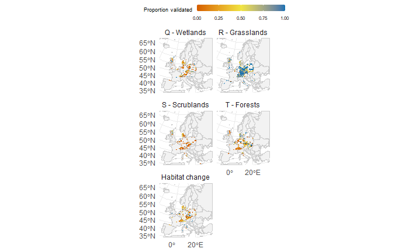

```r
# 1) Create a regular grid over your bbox
cell_km <- 50
grid_3035 <- st_make_grid(
  europe_bbox_3035,
  cellsize = cell_km * 1000,
  what = "polygons",
  square = TRUE
) |>
  (\(g) st_sf(grid_id = seq_len(length(g)), geometry = g))()

# 2) Keep only grid cells that overlap your area of interest (optional)
grid_3035 <- st_intersection(grid_3035, st_as_sf(world_3035_crop))

plots_3035_crop <- st_crop(plots_3035, europe_bbox_3035)

# 3) Spatial join: assign each point to a grid cell
# (st_join on polygons brings grid_id onto points)
pts_with_grid <- st_join(
  plots_3035_crop %>% # points, filter only validated / invalidated
    filter(valid_status_new == "not_valid" | valid_status_new == "valid"),
  grid_3035["grid_id"],           # only keep grid_id column from grid
  left = FALSE                    # drop points outside the grid
)

# 4) Aggregate by grid_id and EUNIS category
agg <- pts_with_grid |>
  st_drop_geometry() |>
  mutate(
    # ensure EUNIS "Change" is last if you facet later (optional)
    EUNIS = fct_relevel(EUNIS, "Change", after = Inf),
    is_valid = case_when(
      valid_status_new == "valid" ~ 1L,
      TRUE ~ 0L
    )
  ) |>
  group_by(grid_id, EUNIS) |>
  summarise(
    n_total = n(),
    n_valid = sum(is_valid, na.rm = TRUE),
    .groups = "drop"
  ) |>
  mutate(
    prop_valid = if_else(n_total > 0, n_valid / n_total, NA_real_)
  )

# 5) Join back to grid polygons
grid_agg <- grid_3035 |>
  inner_join(agg, by = "grid_id")

map_grid_plots <- ggplot() +
  geom_sf(data = world_3035_crop, fill = "grey95", color = "grey80", linewidth = 0.2) +
  geom_sf(data = grid_agg, aes(fill = prop_valid), color = NA) +   # no borders for speed
  facet_wrap(
    ~ EUNIS,
    nrow = 3,
    ncol = 2,
    labeller = labeller(EUNIS = c("Q" = "Q - Wetlands", "R" = "R - Grasslands",
                                   "S" = "S - Scrublands", "T" = "T - Forests",
                                   "Change" = "Habitat change"))) +
  scale_fill_gradientn(
    colours = c("#D55E00", "#F0E442", "#0072B2"),    # orange → yellow → blue
    values = rescale(c(0, 0.5, 1)),
    limits = c(0, 1),
    oob = squish,
    na.value = "grey90",
    name = "Proportion validated"
  ) +
  theme_minimal() +
  theme(
    legend.position = "top",
    legend.justification = c("center", "top"),
    # Tighten the legend itself
    legend.margin = margin(t = 0, r = 0, b = 0, l = 0),
    # Pull the legend box closer to the panels (reduce bottom gap)
    legend.box.margin = margin(t = 0, r = 0, b = -6, l = 0),
    # Keep a little top plot margin so nothing clips
    plot.margin = margin(t = 6, r = 0, b = 5, l = 0),
    panel.spacing = unit(6, "pt"),
    legend.key.size = unit(0.3, "lines"),
    legend.text = element_text(size = 6),
    legend.title = element_text(size = 7)
  ) +
  coord_sf(expand = FALSE) +
  guides(
  fill = guide_colorbar(
    barwidth = unit(4, "cm"),   # increase width
    barheight = unit(0.3, "cm"),  # keep it thin
    title.vjust = 0.8
  )
)
map_grid_plots
```

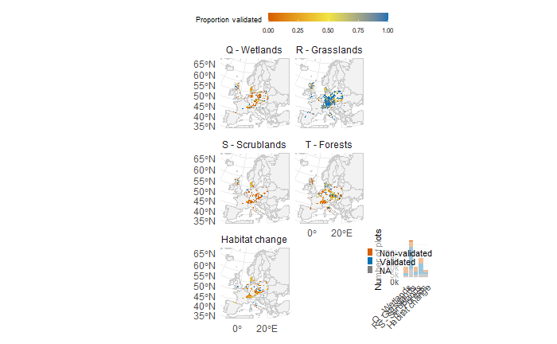

```r
plot_plots_inset <- plot_plots +
  theme(
    aspect.ratio = 3/2,        # height / width  → tall & thin (try 3/1, 4/1, 5/1)
    plot.margin  = margin(0, 0 , 0, 0),
    axis.text.x  = element_text(angle = 45, size = 8, vjust = 1, hjust = 1),
    axis.text.y  = element_text(size = 8, vjust = 1, hjust = 1),
    axis.title.y = element_text(size = 8),
    legend.title = element_blank(),
    legend.text  = element_text(size = 8),
    legend.key.size = unit(6, "pt"),

    # 🔹 Put legend inside, top-right of inset
    legend.position = c(1.4, 0.98),
    legend.justification = c(1, 1),

    # 🔹 Semi-transparent background helps readability
    legend.background = element_rect(fill = alpha("white", 0.6), color = NA)
  ) +
  coord_cartesian(clip = "off", expand = FALSE)

map_plots_with_inset <- map_grid_plots +
  inset_element(
    plot_plots_inset,
    left   = 0.45,
    right  = 0.97,
    bottom = -0.05,
    top    = 0.3,
    align_to = "panel"
  )

map_plots_with_inset +
  theme(plot.margin = margin(1, 1, 1, 1))

ggsave(here("output", "figures", "manuscript", "fig4.jpeg"),
       dpi = 300, width = 5, height = 8)
```

# (Appendix 10): Maps + graph validated obs

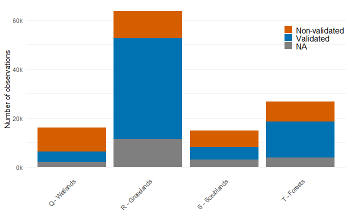

```r
plot_obs <- data_validated_clean %>%
  count(EUNIS1, valid_Landsat, name = "n") %>%
  ggplot(aes(x = EUNIS1, y = n, fill = valid_Landsat)) +
  geom_col(position = position_stack()) +
  xlab(NULL) + ylab("Number of observations") +
  scale_y_continuous(labels = label_number(scale = 1e-3, suffix = "k")) +
  scale_fill_manual(values = c("FALSE" = "#D55E00", "TRUE" = "#0072B2",
                               "NA" = "#828282"),
                    labels = c("FALSE" = "Non-validated",
                               "TRUE" = "Validated",
                               "NA"        = "NA"),
                     name = "Validated") +
  scale_x_discrete(
    labels = function(x) {
      x <- ifelse(x == "Q", "Q - Wetlands", x)
      x <- ifelse(x == "R", "R - Grasslands", x)
      x <- ifelse(x == "S", "S - Scrublands", x)
      x <- ifelse(x == "T", "T - Forests", x)
      x
      }
    ) +
  theme_minimal() + theme(legend.position = c(0.9, 0.8)) +
  theme(axis.text.x = element_text(angle = 45, hjust = 1)) +
  theme(panel.grid.major.x = element_blank(),
        panel.grid.minor.x = element_blank(),
        legend.title = element_blank(),
        legend.text  = element_text(size = 12),
        legend.key.size = unit(12, "pt"))
plot_obs
```

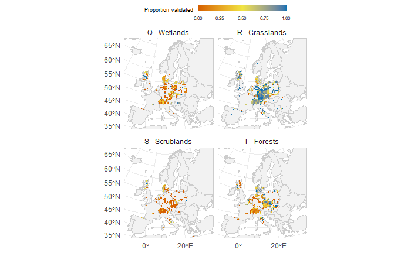

```r
# 1) Create a regular grid over your bbox
cell_km <- 50
grid_3035 <- st_make_grid(
  europe_bbox_3035,
  cellsize = cell_km * 1000,
  what = "polygons",
  square = TRUE
) |>
  (\(g) st_sf(grid_id = seq_len(length(g)), geometry = g))()

# 2) Keep only grid cells that overlap your area of interest (optional)
grid_3035 <- st_intersection(grid_3035, st_as_sf(world_3035_crop))

points_3035_crop <- st_crop(points_3035, europe_bbox_3035)

# 3) Spatial join: assign each point to a grid cell
# (st_join on polygons brings grid_id onto points)
pts_with_grid <- st_join(
  points_3035_crop %>% # points, filter only validated / invalidated
    filter(valid_Landsat == "TRUE" | valid_Landsat == "FALSE"),
  grid_3035["grid_id"],           # only keep grid_id column from grid
  left = FALSE                    # drop points outside the grid
)

# 4) Aggregate by grid_id and EUNIS category
agg <- pts_with_grid |>
  st_drop_geometry() |>
  mutate(
    is_valid = case_when(
      valid_Landsat== "TRUE" ~ 1L,
      TRUE ~ 0L
    )
  ) |>
  group_by(grid_id, EUNIS1) |>
  summarise(
    n_total = n(),
    n_valid = sum(is_valid, na.rm = TRUE),
    .groups = "drop"
  ) |>
  mutate(
    prop_valid = if_else(n_total > 0, n_valid / n_total, NA_real_)
  )

# 5) Join back to grid polygons
grid_agg <- grid_3035 |>
  inner_join(agg, by = "grid_id")

map_obs_plots <- ggplot() +
  geom_sf(data = world_3035_crop, fill = "grey95", color = "grey80", linewidth = 0.2) +
  geom_sf(data = grid_agg, aes(fill = prop_valid), color = NA) +   # no borders for speed
  facet_wrap(
    ~ EUNIS1,
    nrow = 3,
    ncol = 2,
    labeller = labeller(EUNIS1 = c("Q" = "Q - Wetlands", "R" = "R - Grasslands",
                                   "S" = "S - Scrublands", "T" = "T - Forests"))) +
  scale_fill_gradientn(
    colours = c("#D55E00", "#F0E442", "#0072B2"),    # orange → yellow → blue
    values = rescale(c(0, 0.5, 1)),
    limits = c(0, 1),
    oob = squish,
    na.value = "grey90",
    name = "Proportion validated"
  ) +
  theme_minimal() +
  theme(
    legend.position = "top",
    legend.justification = c("center", "top"),
    # Tighten the legend itself
    legend.margin = margin(t = 0, r = 0, b = 0, l = 0),
    # Pull the legend box closer to the panels (reduce bottom gap)
    legend.box.margin = margin(t = 0, r = 0, b = -6, l = 0),
    # Keep a little top plot margin so nothing clips
    plot.margin = margin(t = 6, r = 0, b = 5, l = 0),
    panel.spacing = unit(6, "pt"),
    legend.key.size = unit(0.3, "lines"),
    legend.text = element_text(size = 6),
    legend.title = element_text(size = 7)
  ) +
  coord_sf(expand = FALSE) +
  guides(
  fill = guide_colorbar(
    barwidth = unit(4, "cm"),   # increase width
    barheight = unit(0.3, "cm"),  # keep it thin
    title.vjust = 0.8
  )
)
map_obs_plots
```

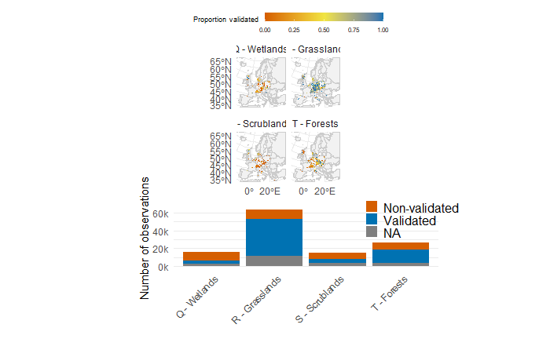

```r
(map_obs_plots /
(
  (plot_spacer() | plot_obs | plot_spacer()) +
    plot_layout(widths = c(1, 3, 1))    # ← side padding : middle column is the plot
)
)  +
  plot_layout(heights = c(4, 2)) +
  theme(plot.margin = margin(1, 1, 1, 1))
ggsave(here("output", "figures", "manuscript", "appendix10.jpeg"),
       dpi = 300, width = 5, height = 8)
```

# (Fig 3) Plots most influential variables

In these plots, include only obs where valid_Landsat == T or valid_Landsat == F, not obs where valid is NA. I.e. include obs where we had data from all predictors, and where able to get a prediction from the RF models.

```r
plot1_Landsat <- data_validated_clean %>%
  mutate(EUNIS1 = factor(EUNIS1, levels = c("Q", "R", "S", "T"))) %>%
  filter(!is.na(valid_Landsat)) %>%
  left_join(data_validation %>%
              select(PlotObservationID, NDMI_max)) %>%
  distr_plot("NDMI_max", "Maximum NDMI", grey = F) +
  theme(plot.margin = margin(2, 2, 2, 2)) +
  scale_x_discrete(limits = c("T", "S", "R", "Q"))
plot2_Landsat <- data_validated_clean %>%
  mutate(EUNIS1 = factor(EUNIS1, levels = c("Q", "R", "S", "T"))) %>%
  filter(!is.na(valid_Landsat)) %>%
  left_join(data_validation %>%
              select(PlotObservationID, SAVI_avg_value_03)) %>%
  distr_plot("SAVI_avg_value_03",
             "SAVI at greening", grey = F) +
  theme(axis.title.y = element_blank(),
        axis.text.y  = element_blank(),
        axis.ticks.y = element_blank()) +
  theme(plot.margin = margin(2, 2, 2, 2)) +
  scale_x_discrete(limits = c("T", "S", "R", "Q"))
plot3_Landsat <- data_validated_clean %>%
  mutate(EUNIS1 = factor(EUNIS1, levels = c("Q", "R", "S", "T"))) %>%
  filter(!is.na(valid_Landsat)) %>%
  left_join(data_validation %>%
              select(PlotObservationID, NDVI_diff_pos_march_value)) %>%
  distr_plot("NDVI_diff_pos_march_value",
             "Difference in NDVI between peak and greening",
             grey = F) +
  theme(plot.margin = margin(2, 2, 2, 2)) +
  scale_x_discrete(limits = c("T", "S", "R", "Q"))
plot4_Landsat <- data_validated_clean %>%
  mutate(EUNIS1 = factor(EUNIS1, levels = c("Q", "R", "S", "T"))) %>%
  filter(!is.na(valid_Landsat)) %>%
  left_join(data_validation %>%
              select(PlotObservationID, NDVI_auc_mar_oct)) %>%
  distr_plot("NDVI_auc_mar_oct",
             "AUC for NDVI", grey = F) +
  theme(axis.title.y = element_blank(),
        axis.text.y  = element_blank(),
        axis.ticks.y = element_blank()) +
  theme(plot.margin = margin(2, 2, 2, 2)) +
  scale_x_discrete(limits = c("T", "S", "R", "Q"))
plot5_Landsat <- data_validated_clean %>%
  mutate(EUNIS1 = factor(EUNIS1, levels = c("Q", "R", "S", "T"))) %>%
  filter(!is.na(valid_Landsat)) %>%
  left_join(data_validation %>%
              select(PlotObservationID, NDWI_min)) %>%
  distr_plot("NDWI_min",
             "Minimum NDWI", grey = F) +
  theme(plot.margin = margin(2, 2, 2, 2)) +
  scale_x_discrete(limits = c("T", "S", "R", "Q"))
plot_for_legend <- data_validated_clean %>%
  mutate(EUNIS1 = factor(EUNIS1, levels = c("Q", "R", "S", "T"))) %>%
  filter(!is.na(valid_Landsat)) %>%
  left_join(data_validation %>%
              select(PlotObservationID, NDMI_max)) %>%
  distr_plot("NDMI_max", "Maximum NDMI", grey = FALSE) +
  guides(fill = guide_legend(), color = guide_legend()) +
  labs(fill = "EUNIS level 1", color = "EUNIS level 1") +
  theme(legend.position = "right") +
  scale_fill_manual(values = c("#0072B2", "#D55E00", "#009E73", "#CC79A7"),
                    breaks = c("Q", "R", "S", "T"),
                    labels = c("Q" = "Q - Wetlands","R" = "R - Grasslands",
                               "S" = "S - Scrublands", "T" = "T - Forests")) +
  scale_color_manual(values = c("#0072B2", "#D55E00", "#009E73", "#CC79A7"),
                     breaks = c("Q", "R", "S", "T"),
                     labels = c("Q" = "Q - Wetlands","R" = "R - Grasslands",
                               "S" = "S - Scrublands", "T" = "T - Forests")) +
  guides(fill = guide_legend(
    override.aes = list(shape = 22, size = 8,
                        fill = c("#0072B2", "#D55E00", "#009E73", "#CC79A7"),
                        color = NA, linetype = 0, alpha = 1)),
    color = "none") +
  theme(legend.text = element_text(size = 12),
        legend.title = element_text(size = 13)) +
  scale_x_discrete(limits = c("Q", "R", "S", "T"))
legend <- patchwork::wrap_elements(get_legend(plot_for_legend))
```

```r
fig3 <- (
    plot1_Landsat + theme(plot.margin = margin(2,2,2,2)) |
      plot2_Landsat + theme(plot.margin = margin(2,2,2,2))
    ) /
  (plot3_Landsat + theme(plot.margin = margin(2,2,2,2)) |
     plot4_Landsat + theme(plot.margin = margin(2,2,2,2))
   ) /
  (plot5_Landsat + theme(plot.margin = margin(2,2,2,2)) |
    legend
  ) +
  plot_layout(heights = c(1,1,1)) &
  theme(plot.margin = margin(2,2,2,2))

ggsave(here("output", "figures", "manuscript", "fig3.jpeg"), plot = fig3,
       dpi = 300, width = 7, height = 9)
```

# (Appendix 4) Plot GPS observations used for models

```r
filter_data_Landsat <- function(data, variables) {
  data %>%
    mutate(EUNIS1 = as.factor(EUNIS1)) %>%
    # Remove rows with missing values in predictors
    dplyr::filter(if_all(all_of(variables), ~ !is.na(.))) %>%
    # Remove all rows with wrong values of indices (not between -1 and 1)
    dplyr::filter(NDVI_max <= 1 & NDVI_min >= -1) %>%
    # With Landsat data, many observations removed because of high/low EVI values
    # In Landsat_extraction, values of EVI outside of expected range were set as NA,
    # so better not to use EVI here
    # dplyr::filter(EVI_max <= 1 & EVI_min >= -1) %>%
    dplyr::filter(SAVI_max <= 1 & SAVI_min >= -1) %>%
    dplyr::filter(NDMI_max <= 1 & NDMI_min >= -1) %>%
    dplyr::filter(NDWI_max <= 1 & NDWI_min >= -1) %>%
    # Select only variables needed
    dplyr::select(PlotObservationID, EUNIS1, all_of(variables),
           valid_1) %>%
    # Keep only rows with differences > 0 in variables
    filter(if_all(any_of(variables[grepl("diff", variables)]),
                  ~ .x > 0))
}
```

```r
data_models <- filter_data_Landsat(
  data_validation %>%
    rough_validation_Landsat(), # Rough validation based on NDWI
  vars_RF_months_Landsat) %>%
  left_join(data_V2025.2 %>%
              # Update coordinates
              mutate(Lon_updated = ifelse(is.na(Lon_prec), Longitude, Lon_prec),
                     Lat_updated = ifelse(is.na(Lat_prec), Latitude, Lat_prec)) %>%
              select(PlotObservationID, `Location method`, Lon_updated, Lat_updated)) %>%
  mutate(GPS = case_when(`Location method` %in%
                           c("Location with GPS",
                             "Location with differential GPS") ~ TRUE,
                         !`Location method` %in%
                           c("Location with GPS",
                             "Location with differential GPS") ~ FALSE,
                         is.na(`Location method`) ~ FALSE))
```

```r
points_3035 <- st_as_sf(data_models,
                        coords = c("Lon_updated", "Lat_updated"),
                        crs = 4326
                        ) |>
  st_transform(3035)

points_3035_crop <- st_crop(points_3035, europe_bbox_3035)
```

```r
# 1) Create a regular grid over your bbox
cell_km <- 50
grid_3035 <- st_make_grid(
  europe_bbox_3035,
  cellsize = cell_km * 1000,
  what = "polygons",
  square = TRUE
) |>
  (\(g) st_sf(grid_id = seq_len(length(g)), geometry = g))()

# 2) Keep only grid cells that overlap your area of interest (optional)
grid_3035 <- st_intersection(grid_3035, st_as_sf(world_3035_crop))

points_3035_crop <- st_crop(points_3035_crop, europe_bbox_3035)

# 3) Spatial join: assign each point to a grid cell
# (st_join on polygons brings grid_id onto points)
pts_with_grid <- st_join(
  points_3035_crop,
  grid_3035["grid_id"],           # only keep grid_id column from grid
  left = FALSE                    # drop points outside the grid
)

# 4) Aggregate by grid_id and EUNIS category
agg <- pts_with_grid |>
  st_drop_geometry() |>
  group_by(grid_id, EUNIS1) |>
  summarise(
    n_total = n(),
    n_GPS = sum(GPS, na.rm = TRUE),
    .groups = "drop"
  ) |>
  mutate(
    prop_GPS = if_else(n_total > 0, n_GPS / n_total, NA_real_)
  )

# 5) Join back to grid polygons
grid_agg <- grid_3035 |>
  inner_join(agg, by = "grid_id")

map_grid_GPS <- ggplot() +
  geom_sf(data = world_3035_crop, fill = "grey95", color = "grey80", linewidth = 0.2) +
  geom_sf(data = grid_agg, aes(fill = prop_GPS), color = NA) +   # no borders for speed
  facet_wrap(
    ~ EUNIS1,
    nrow = 2,
    ncol = 2,
    labeller = labeller(EUNIS1 = c("Q" = "Q - Wetlands", "R" = "R - Grasslands",
                                   "S" = "S - Scrublands", "T" = "T - Forests"))) +
  scale_fill_gradientn(
    colours = c("#009E73", "#D3D3D3", "#CC79A7"),  # green → light grey → purple
    values = rescale(c(0, 0.5, 1)),
    limits = c(0, 1),
    oob = squish,
    na.value = "grey90",
    name = "Proportion GNSS"
  ) +
  theme_minimal() +
  theme(
    legend.position = "top",
    legend.justification = c("center", "top"),
    # Tighten the legend itself
    legend.margin = margin(t = 0, r = 0, b = 0, l = 0),
    # Pull the legend box closer to the panels (reduce bottom gap)
    legend.box.margin = margin(t = 0, r = 0, b = -6, l = 0),
    # Keep a little top plot margin so nothing clips
    plot.margin = margin(t = 6, r = 0, b = 5, l = 0),
    panel.spacing = unit(6, "pt"),
    legend.key.size = unit(0.3, "lines"),
    legend.text = element_text(size = 6),
    legend.title = element_text(size = 7)
  ) +
  coord_sf(expand = FALSE) +
  guides(
  fill = guide_colorbar(
    barwidth = unit(4, "cm"),   # increase width
    barheight = unit(0.3, "cm"),  # keep it thin
    title.vjust = 0.8
  )
)
```

[output not shown]